# Automating ggplot graphs in R?

# 1 Introduction

In this lesson, we will explore how to automate data visualizations using the powerful combination of `{{ggplot2}}` and `{{purrr}}` in R. We’ll begin by identifying scenarios where automated plotting can greatly enhance your data analysis workflows. From there, we’ll delve into the programmatic side of `{{ggplot2}}`, creating custom plotting functions to streamline your graphing tasks. We’ll harness the capabilities of `{{purrr}}` to iterate through datasets and variables, allowing us to automate repetitive plotting tasks efficiently. As we progress, we’ll learn how to create complex, dynamic visualizations and even combine multiple plots into cohesive presentations. By the end of this lesson, you’ll have the skills to automate `{{ggplot2}}` graphs, saving time and enhancing the reproducibility of your data-driven narratives.

# 2 Learning Objectives

1. **Recognize Repetitive Plotting and Establish Workflow**: Identify when repetitive plotting is needed and create a workflow involving data subsetting, plotting, and saving.
2. **Basics of `{{ggplot2}}` and Faceting**: Learn to use `{{ggplot2}}` for data visualization and faceting to create shared-axis subplots. Discuss the limitations of manual faceting and the importance of automation.
3. **Custom Plotting Functions and Subsetting with `{{purrr}}`**: Develop custom functions for repetitive plotting tasks, including variable and row subsetting, with the help of `{{purrr}}`. Learn to add parameters for dynamic plot customization.
4. **Combine and Customize Plots**: Use `{{patchwork}}` to combine plots and apply further customizations with `{{ggplot2}}`.
5. **File Paths and Saving Plots**: Learn to set file paths with the `{{here}}` package and save plots efficiently with `{{ggsave}}` for easier reuse.

# 3 Packages

In this lesson we will use the following packages :

- `{{tidyverse}}` specifically we will focus on `{{ggplot2}}` and `{{purrr}}`
- `{{glue}}` and `{{patchwork}}`

# 4 Intro to the Dataset

The dataset at our disposal originates from the Naomi-Spectrum dashboard, where data was gathered and harmonized to compile this comprehensive file. To provide context, it’s essential to note that the Naomi model serves as the endorsed tool employed by UNAIDS, PEPFAR, and various other regional entities for the purpose of generating sub-national HIV estimates. These estimates are instrumental in guiding planning, monitoring progress, and establishing crucial targets within the region.

The table provides information on various variables related to demographic and statistical indicators for a specific population dataset:

- **area_level**: Geographical area level.
- **area_level_label**: Label describing the area level.
- **area_id**: Area identifier.
- **area_name**: Area name.
- **sex**: Gender category.
- **age_group**: Age group.
- **age_group_label**: Label describing the age group.
- **calendar_quarter**: Calendar quarter.
- **quarter_label**: Label describing the calendar quarter.
- **indicator**: Type of indicator.
- **indicator_label**: Label describing the indicator.
- **mean**: Mean value.
- **se**: Standard error.
- **median**: Median value.
- **mode**: Mode value.

- **`Prevalence`**: The percentage of individuals within a specific population who are currently living with HIV, indicating the extent of the HIV epidemic within that group.
- **`ANC Prevalence`**: The percentage of pregnant women in a population who have tested positive for HIV during antenatal care visits, helping assess HIV prevalence among expectant mothers.

Let’s do this directly to our data import and keep the columns we need:

```r
hiv_indicators <- read_csv(here::here("data/clean/all_indicators_hiv_malawi_naomi.csv")) %>%
  filter(indicator  %in% c("anc_prevalence", "prevalence")) %>%
  select(
    area_level,
    area_id,
    area_name,
    sex,
    age_group_label,
    quarter_label,
    indicator,
    mean
  )
```

Now we are ready to dig in.

# 5 Simple faceting and repetitive plotting

In this section, we will leverage our available data to highlight both the benefits and limitations of faceting, shedding light on potential challenges, particularly when crafting a report.

Now, let’s start with a practical question, how can we effectively visualize variations in HIV prevelance of Malawi across different age groups and regions in December 2022? To address this question, we introduce the concept of faceting—a powerful data visualization technique [you can refer to our course about `{{ggplot2}}` for more details]. Faceting enables us to break down complex questions like this one into more manageable subsets, each represented by its own plot. By doing so, we uncover valuable insights that might remain hidden in a single, comprehensive view. In the context of our data analysis, faceting proves invaluable for highlighting patterns, relationships, and variations among different age groups, making it an essential tool for exploring multifaceted questions.

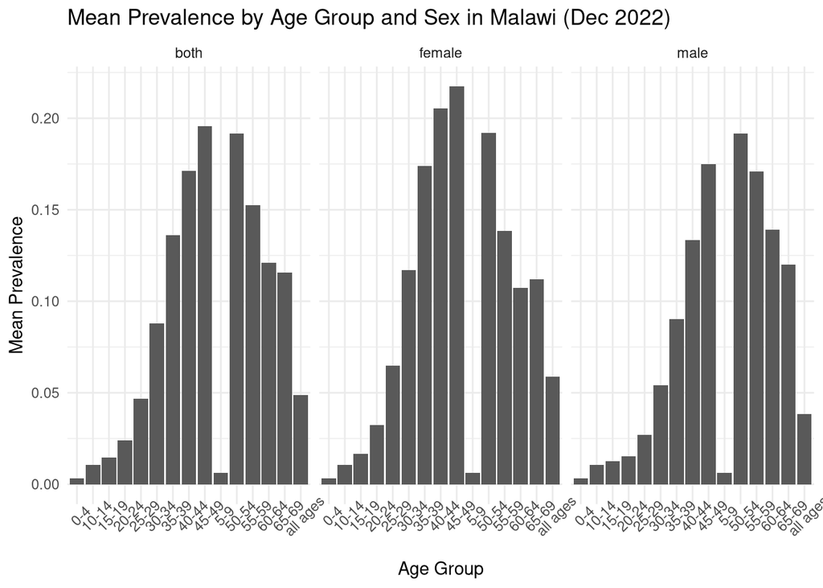

```r
# Create a faceted boxplot to visualize population variations by age group
hiv_indicators %>%
  filter(
    indicator == 'prevalence' & area_level == 0
  ) %>%
  ggplot() +
  geom_col(
    aes(
      x = age_group_label,
      y = mean
    )
  ) +
  labs(x = "Age Group", y = "Mean Prevalence") +
  ggtitle("Mean Prevalence by Age Group and Sex in Malawi (Dec 2022)") +
  theme_minimal() +
  facet_wrap(~ sex) +
  # changing the angle of the x axis text so it's readable
  theme(
    axis.text.x =  element_text(angle = 45)
  )
```

This code breaks down the dimensions within the data, which helps us present more information in one graph.

As we delve into the dimensions of our data, a critical question arises: How can we effectively portray HIV prevalence, spanning various subgroups? These subgroups encompass a rich mix of indicators, regions, and demographic attributes, including age groups and sexes. While our goal is to maintain the consistency and comprehensibility of our visualizations, the traditional approach of faceting falls short when faced with this complexity.

The Challenge of Faceting:

To illustrate this challenge, let’s consider the following code snippet:

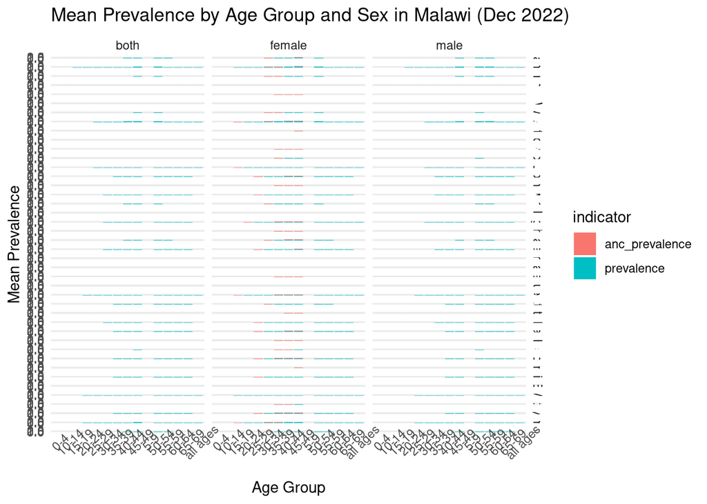

```r
hiv_indicators %>%
  # we remove all filters
  # filter(
  #   indicator == 'prevalence' &
  #     area_level == 0
  # ) %>%
  ggplot() +
  geom_col(
    aes(
      x = age_group_label,
      y = mean,
      # we add the indicators to a color fill scale
      fill = indicator
    )
  ) +
  labs(x = "Age Group", y = "Mean Prevalence") +
  ggtitle("Mean Prevalence by Age Group and Sex in Malawi (Dec 2022)") +
  theme_minimal() +
  facet_grid(area_name~sex) +
  # changing the angle of the x axis text so it's readable
  theme(
    axis.text.x =  element_text(angle = 45)
  )
```

Even though we tried our best with faceting, we sometimes end up with visual clutter that makes it hard to grasp complex data. This happens because faceting, while handy in many situations, struggles when dealing with diverse datasets that have lots of different aspects.

The solution is to take a more organized and practical approach, one that combines the flexibility of `{{ggplot2}}` with functional programming. Instead of sticking solely to faceting, we can use tools like `{{purrr}}` to create a series of plots systematically. This approach helps us cut through the complexity and get a clear view of our data, making it easier to uncover valuable insights from even the most intricate datasets.

**Question 1: Automated Visualization of TB Incidence (example)**

You have a dataset named **`tb_data`** containing tuberculosis (TB) incidence rates across different age groups and regions. You want to create an automated visualization to compare the TB incidence distribution among age groups in a specific region. Which code snippet demonstrates the correct use of **`ggplot2`** for this task?

```r
tb_region <- "RegionX"

tb_data %>%
  filter(region == tb_region) %>%
  ggplot() +
  geom_boxplot(aes(x = age_group, y = incidence_rate)) +
  labs(x = "Age Group", y = "Incidence Rate", title = paste("TB Incidence in", tb_region)) +
  theme_minimal()
```

```r
tb_region <- "RegionX"

tb_data %>%
  filter(region == tb_region) %>%
  ggplot() +
  geom_col(aes(x = age_group, y = incidence_rate)) +
  labs(x = "Age Group", y = "Incidence Rate", title = paste("TB Incidence in", tb_region)) +
  theme_minimal()
```

```r
tb_region <- "RegionX"

tb_data %>%
  filter(region == tb_region) %>%
  ggplot() +
  geom_boxplot(aes(x = incidence_rate, y = age_group)) +
  labs(x = "Incidence Rate", y = "Age Group", title = paste("TB Incidence in", tb_region)) +
  theme_minimal()
```

```r
tb_region <- "RegionX"

tb_data %>%
  filter(region == tb_region) %>%
  ggplot() +
  geom_col(aes(x = incidence_rate, y = age_group)) +
  labs(x = "Incidence Rate", y = "Age Group", title = paste("TB Incidence in", tb_region)) +
  theme_minimal()`
```

# 6 Efficient Data Visualization with Custom Functions in `{{ggplot2}}`

When exploring datasets, we often generate multiple plots to understand various aspects of the data. To optimize this process, we can use custom functions in `{{ggplot2}}`, which help automate repetitive tasks and facilitate a more comprehensive data exploration.

## 6.1 A Simple Plotting Function

Let’s start by creating a function that accepts a data frame, an indicator, and an area level as inputs. We will use these variables to filter the data, and the selected indicator and area level will be highlighted in our plot.

Let’s break down what we want our function to do :

```r
create_plot <- function(data, indicator, area_level) {

  # Check if input is valid
  if (!indicator %in% data$indicator) stop("Indicator not listed in the data set.")
  if (!area_level %in% data$area_level) stop("Area level not listed in the data set.")

  ggplot(
    data = filter(
      data,
      indicator == indicator & area_level == area_level
    )
  ) +
    # Filter for the indicator and area level of interest
    geom_col(
      aes(
        x = age_group_label,
        y = mean
      )
    ) +
    # Add title automatically based on subset choice
    labs(
      x = "Age Group",
      y = "Mean Prevalence",
      title = paste0(indicator, " at Area Level ", area_level, " (Dec 2022)") # note the use of paste0 to create custom labels
    ) +
    theme_minimal() +
    facet_wrap(~ sex) +
    theme(
      axis.text.x =  element_text(angle = 45)
    )
}
```

We can now use this function to create a plot with our data:

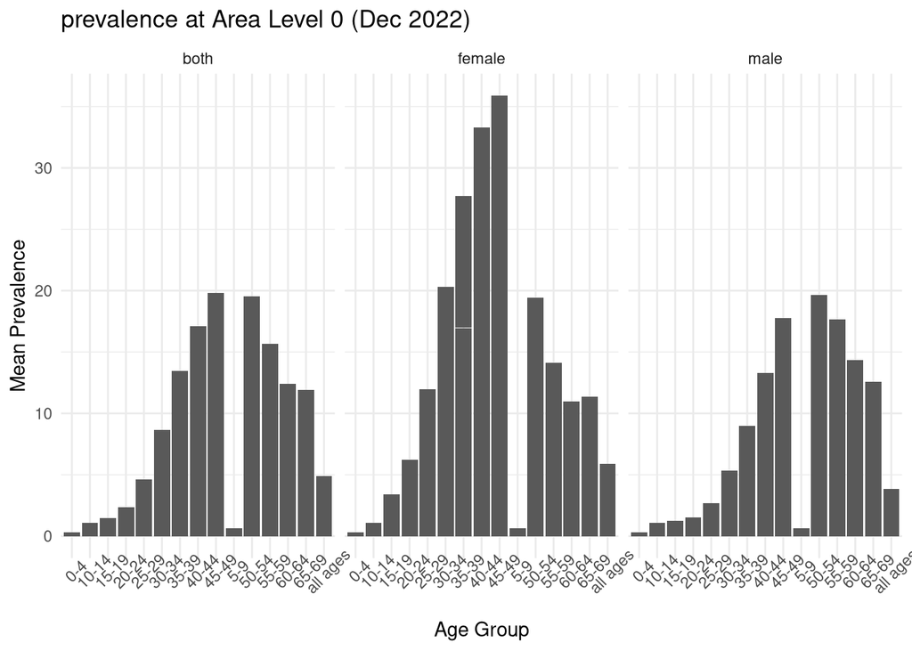

```r
create_plot(hiv_indicators, "prevalence", 0)   # Prevalence at national level
```

Of course we can use this function with multiple combinations, as it can handle any combination of `indicator` and `area_level` from the data. We can use this function to generate multiple plots:

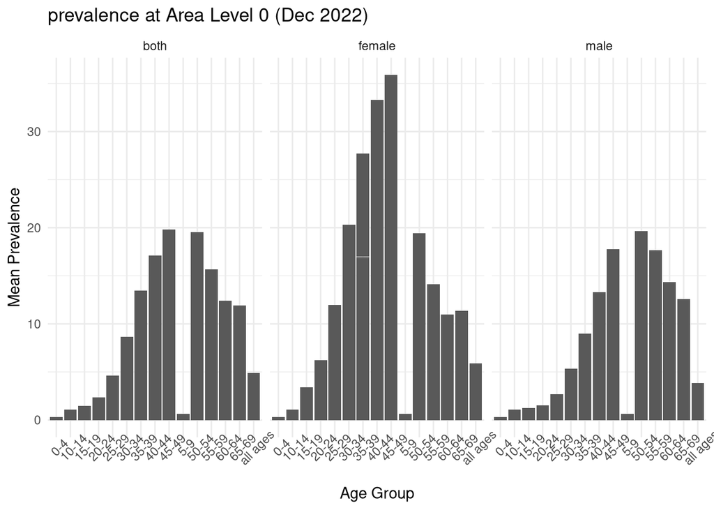

```r
create_plot(hiv_indicators, "prevalence", 0)   # Prevalence at national level
```

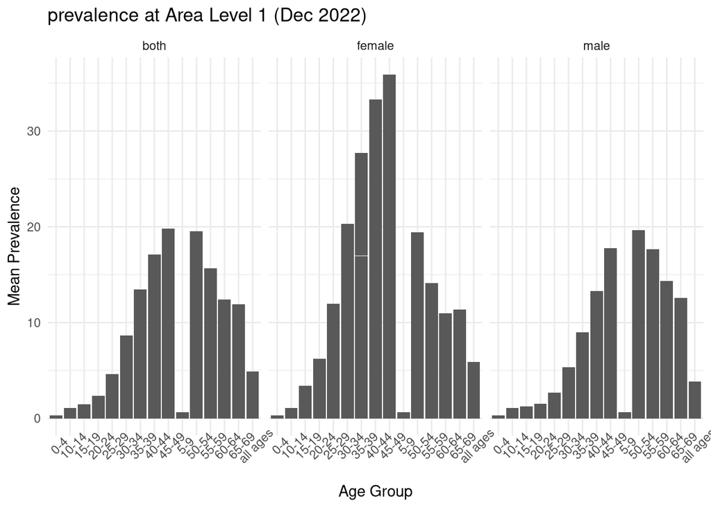

```r
create_plot(hiv_indicators, "prevalence", 1) # ANC Prevalence at regional level
```

Question 2: Custom Plotting Function for Malaria Data

You’re working with a dataset containing malaria prevalence data across different regions and age groups. You want to create a custom plotting function named custom_malaria_plot that generates boxplots for different variables in your dataset, allowing for flexible selection of variables and maintaining a consistent theme. Which code snippet correctly defines this function within the epidemiological context?

```r
custom_malaria_plot <- function(data, x_var, y_var) {
  ggplot(data, aes(x = x_var, y = y_var)) +
    geom_boxplot() +
    theme_minimal()
}
```

```r
custom_malaria_plot <- function(data, x_var, y_var) {
  ggplot(data, aes_string(x = x_var, y = y_var)) +
    geom_col() +
    labs(x = x_var, y = y_var) +
    theme_minimal()
}
```

```r
custom_malaria_plot <- function(data, x_var, y_var) {
  ggplot(data, aes(x = x_var, y = y_var)) +
    geom_col() +
    labs(x = "X-axis", y = "Y-axis") +
    theme_bw()
}
```

```r
custom_malaria_plot <- function(data, x_var, y_var) {
  ggplot(data, aes(x = x_var, y = y_var)) +
    geom_histogram() +
    labs(x = "X-axis", y = "Y-axis") +
    theme_minimal()
}
```

While the code provided is fundamentally sound and makes good use of R’s `{{ggplot2}}`, there is room for improvement when it comes to the aggregation of data and the use of faceting. Currently, the code differentiates the aggregation of data based on a single indicator and area, but the area aggregation will be always the same and won’t provide any difference if we keep using it the way we did, this limit the ability to compare different indicators across various areas. Which is the point of such code in the first place

A more constructive approach would be to incorporate indicator into the faceting of the plots. This way, each facet would represent a different indicator for a different sex, making it easier to compare these indicators across different areas - a clear example of **variable subsetting**. Furthermore, instead of mapping through a single predefined area, the code could be modified to map through an area level of our choosing. This would allow for greater flexibility and customizability in our data visualization, enabling us to create more meaningful and informative plots. The use of the `filter()` function to select specific area levels aligns with the concept of **row subsetting**.

```r
# Define a new function called 'create_plot_2' with parameters 'data' and 'area'
create_plot_2 <- function(data, area) {
  # Start a pipe with 'data' and filter rows where 'area_name' equals the provided 'area'
  data %>%
    filter(
      area_name == area
    ) %>%
    # Start creating a ggplot of the filtered data
    ggplot() +
    # Add bar plot with 'age_group_label' on the x-axis and 'mean' on the y-axis
    geom_col(
      aes(
        x = age_group_label,
        y = mean
      )
    ) +
    # Set the labels of the x-axis, y-axis, and the title of the plot
    labs(
      x = "Age Group",
      y = "Mean Prevalence",
      title = paste0("Area Level ", area, " (Dec 2022)")
    ) +
    # Apply a minimal theme to the plot
    theme_minimal() +
    # Create a grid of plots for each combination of 'indicator' and 'sex' (change from facet_wrap in previous code)
    facet_grid(indicator ~ sex) +
    # Rotate the x-axis text by 45 degrees for better readability
    theme(
      axis.text.x =  element_text(angle = 45)
    )
}
```

Now in order to apply this function over multiple areas, and before using `map()` for that, we need to define a vector containing the name of each of them, then the `map()` function will iterate over that vector, essentially **row subsetting** our data based on area level.

In epidemiological analysis, the geographical context is often pivotal. Different geographical levels, such as country, state, or county, each with their unique names and associated data, frequently necessitate subsetting our datasets based on these area levels.

Consider the following block of code, which is a common pattern for this type of operation:

```r
# First, we create a vector 'areas_3' that contains the unique names of areas where 'area_level' is 3
areas_3 <- hiv_indicators %>%
  filter(area_level == 3) %>%  # Filter rows where 'area_level' is 3
  pull(area_name) %>%  # Extract the column 'area_name'
  unique()  # Retain only unique area names
```

This piece of code is used to find unique area names at the third area level (“area_level” equals 3). While this is functional, repeating such a process each time we need to subset data can be inefficient and lead to cluttered code.

To streamline this process, we can encapsulate this operation into a dedicated helper function. This function, as defined below, will subset our data based on a given area level and extract the unique names within that subset:

```r
# Define the helper function to get unique area names for a specified level
areas <- function(level){
  hiv_indicators %>%
    filter(area_level == level) %>%
    pull(area_name) %>%
    unique() %>%
    return()
}
```

With this function, we can easily and efficiently obtain the unique area names for any specified level. We will use this `areas` function throughout the rest of this lesson to ensure our code remains clean, efficient, and understandable.

```r
# Use the helper function 'areas' to get unique names for area level 3
# Apply 'create_plot_2' to each of these areas using 'map' function
# Store the resulting list of plots in 'plot_list'
plot_list <- map(areas(3), ~ create_plot_2(hiv_indicators, .x))  # '.x' represents each area name
```

In this section, we’ve created a list of plots for each unique level 3 area in the `hiv_indicators` data frame. Now, you can access any plot from this list just like you would access any element in a list:

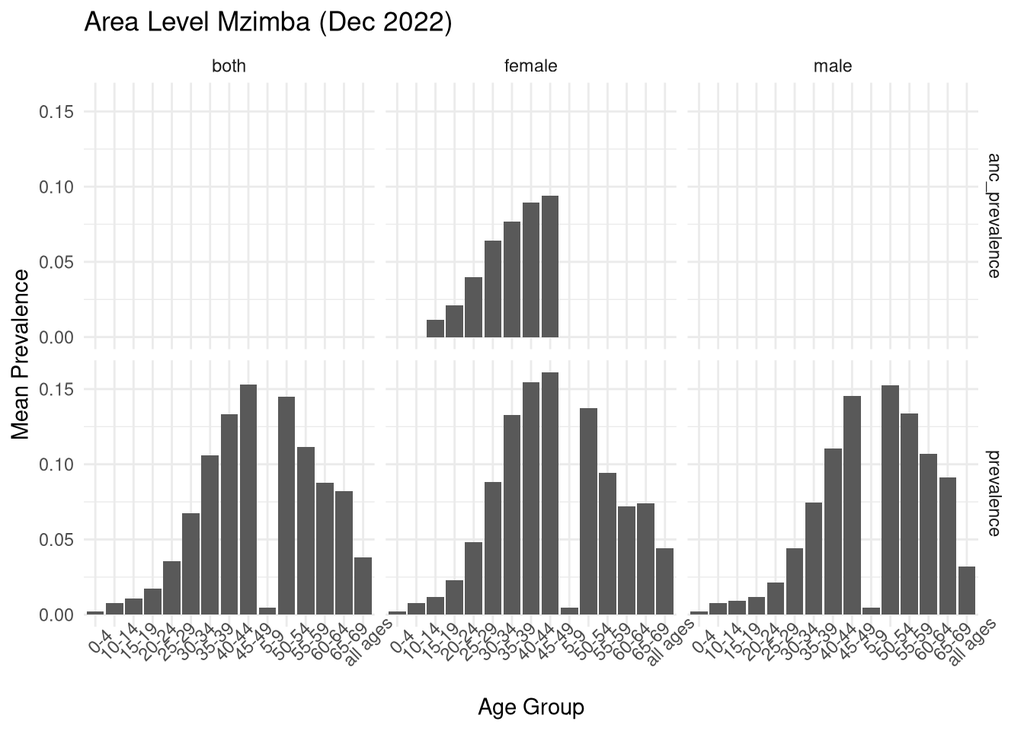

```r
# To access specific plots in the list, we can use index numbers
# For example, to view the 5th plot, we use:
plot_list[[5]]
```

In the visualizations, the age groups aren’t logically ordered, which can make interpretation difficult. We can use R’s factor functionality to correct this.

Here’s how:

```r
# Get unique age group levels
ordered_age_groups <- hiv_indicators %>% pull(age_group_label) %>% unique()

# Reorder age_group_label levels
hiv_indicators <- hiv_indicators %>%
  mutate(
    age_group_label = fct_relevel(age_group_label, ordered_age_groups)
  )
```

We first extract unique age group labels (which to our luck were ordered), then reorder `age_group_label` according to this. The `fct_relevel()` function from `{{forcats}}` package helps us achieve this. The result is a more logically ordered `age_group_label`, improving the clarity of our plots.

This workflow demonstrates the power of automating repetitive tasks in data visualization using both **row subsetting** and **variable subsetting**. By creating a function to generate plots and using `map()` to apply it across different areas, you can quickly generate a series of plots without having to manually create each one. This not only saves time, but allows you to focus more on interpreting your data and less on the mechanics of generating plots. This approach can be extended to other variables and even more complex visualizations, further enhancing your productivity and efficiency.

Question 3: The Concept of Automation in Epidemiological Data Visualization

You are working on an epidemiological research project that involves creating multiple plots to visualize disease patterns across different regions and age groups. Which statement best describes the concept of automation in this context?

1. Automation refers to manually generating each plot to ensure precision in data representation.
2. Automation involves utilizing advanced code structures to create plots quickly without considering data subsets.
3. Automation means using tools like purrr to systematically generate plots for various data subsets, enhancing efficiency.
4. Automation is only useful when working with large datasets; it’s unnecessary for small datasets.

## 6.2 Customizing the Plot Function

In this section, we’ll leverage the power of R to create a flexible, customizable plot function. By adding parameters to our function, we can control various aspects of the plot, such as plot type, aesthetics, and variables to be plotted.

For the examples in this section, we’ll use a dataset named `hiv_indicators`. This dataset contains information on HIV prevalence and ANC prevalence across different age groups, sexes, and geographical areas.

Let’s start by looking at our base function:

```r
create_custom_plot <- function(data, x_var = "age_group_label", y_var = "mean", sex, indicator, area_name, area_level) {

    # Filter data
    plot_data <- data %>%
      filter(
        sex == sex,
        area_name == area_name,
        area_level == area_level,
        indicator == indicator
      )

    # Check if the filtered data is empty
    if (nrow(plot_data) == 0) return(glue("No data for the area: {area_name} with the given filters."))

    # Create base plot with bar plot
    plot <- ggplot(plot_data, aes_string(x = x_var, y = y_var)) + geom_col()

    # Add labels and theme
    plot <- plot +
      labs(
        x = x_var,
        y = y_var,
        title = glue("Distribution of {indicator} across {x_var} in the {area_name} area"),
        subtitle = glue("Gender filter: {sex}")
      ) +
      theme_minimal()

    return(plot)
}
```

With the `create_custom_plot` function, we can adjust the plot type, the x and y variables, and more by simply changing the function parameters.

Here’s an example of how to use the function:

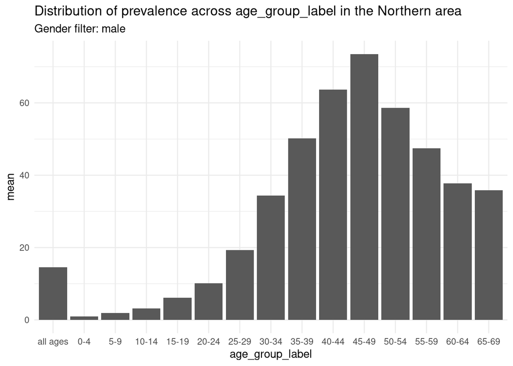

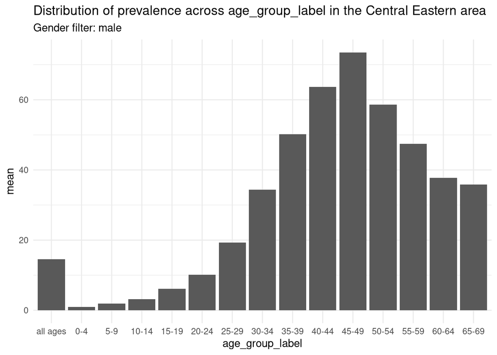

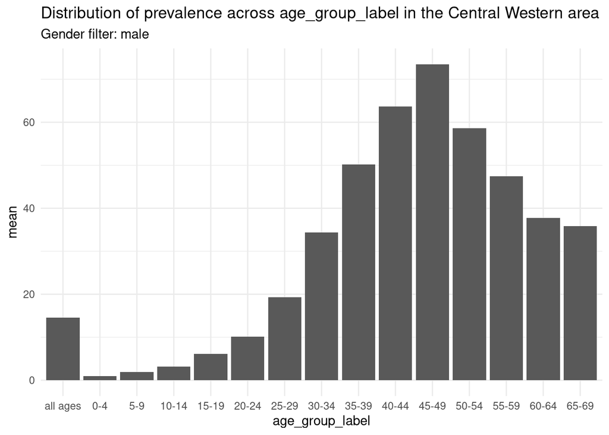

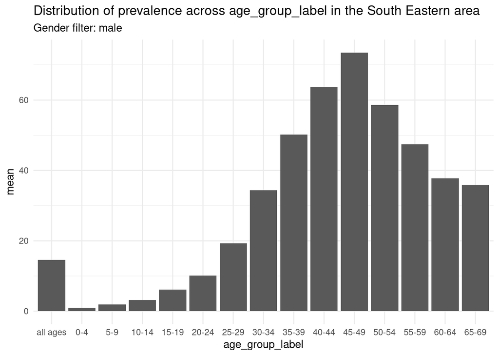

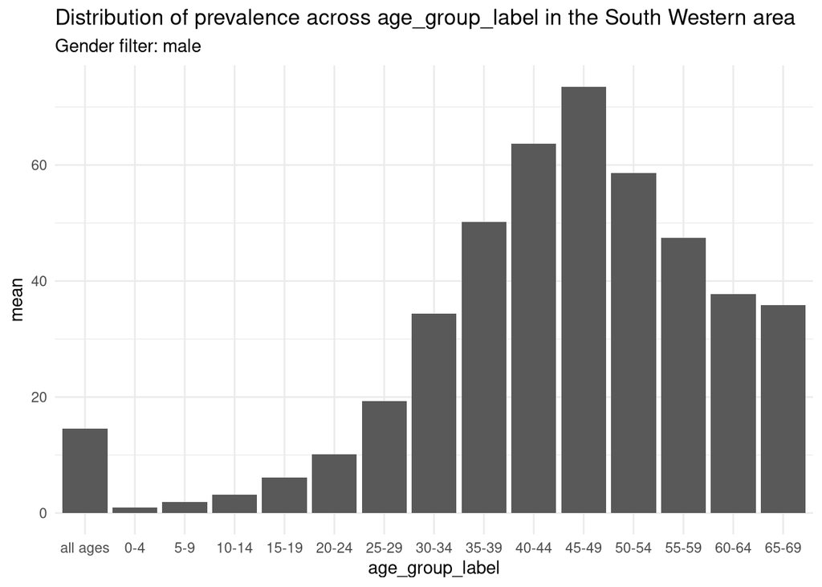

```r
# Here, we assume you have a function named "areas" that returns area names
areas(level = 2) %>%
  map(
    ~ create_custom_plot(data = hiv_indicators, area_name = .x, area_level = 2, x_var = "age_group_label", y_var = "mean", sex = "male", indicator = "prevalence")
  )
```

The `glue` package in R is a tool for string interpolation that allows for the dynamic creation of strings based on R expressions. Unlike `paste0()`, `glue` allows you to embed R expressions directly within curly braces `{}` in the string, which makes the syntax simpler and more readable.

Example with `glue`:

```r
library(glue)

name <- "Alice"

greeting <- glue("Hello, my name is {name}.")

print(greeting)  # "Hello, my name is Alice."
```

Equivalent example with `paste0`:

```r
name <- "Alice"

greeting <- paste0("Hello, my name is ", name, ".")

print(greeting)  # "Hello, my name is Alice."
```

As you can see, `glue` provides a cleaner and more intuitive syntax for string interpolation compared to `paste0()`.

Till now we focused on creating a single plot based on selected filtering criteria with the `create_custom_plot()` function. However, in many cases, it’s more insightful to compare different plots side by side. For this purpose, we can leverage the `{{patchwork}}` package in R, which enables us to combine separate plots into a single layout.

Let’s revise the `create_custom_plot()` function to accommodate this. Our updated function will generate two specific plots and then combine them:

1. A plot showing the prevalence faceted by sex
2. A plot displaying the ANC prevalence for females only

Here is the updated `create_custom_plot()` function:

```r
create_custom_plot <- function(data, x_var = "age_group_label", y_var = "mean", area_name, area_level) {
  library(patchwork)

  # Create the first plot for prevalence
  plot_data1 <- data %>%
    filter(
      area_name == area_name,
      area_level == area_level,
      indicator == "prevalence"
    )

  # Check if the filtered data is empty
  if (nrow(plot_data1) == 0) return(glue("No data for the area: {area_name} with the given filters."))

  # Create base plot with bar plot
  plot1 <- ggplot(plot_data1, aes_string(x = x_var, y = y_var)) +
            geom_col() +
            facet_grid(~sex) +
            labs(
              x = x_var,
              y = y_var,
              title = glue("Prevalence across {x_var} in the {area_name} area"),
              subtitle = "Faceted by sex"
            ) +
            theme_minimal() +
            theme(
              axis.text.x =  element_text(angle = 45)
            )

  # Create the second plot for ANC prevalence
  plot_data2 <- data %>%
    filter(
      sex == "female",
      area_name == area_name,
      area_level == area_level,
      indicator == "anc_prevalence"
    )

  # Check if the filtered data is empty
  if (nrow(plot_data2) == 0) return(glue("No data for the area: {area_name} with the given filters."))

  # Create base plot with bar plot
  plot2 <- ggplot(plot_data2, aes_string(x = x_var, y = y_var)) +
            geom_col() +
            labs(
              x = x_var,
              y = y_var,
              title = glue("ANC Prevalence across {x_var} in the {area_name} area"),
              subtitle = "Female only"
            ) +
            theme_minimal()

  # Combine the two plots
  combined_plot <- plot1 / plot2

  return(combined_plot)
}
```

Here’s how to call the updated function:

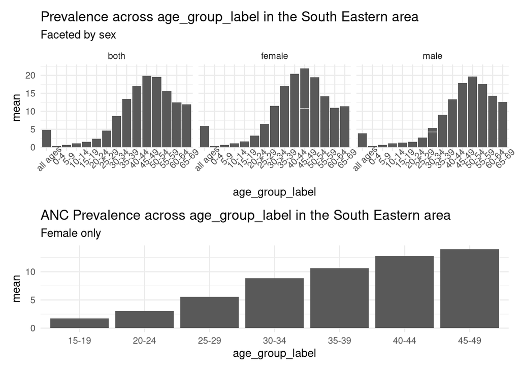

```r
areas_plot <- areas(level = 2) %>%
  map(
    ~ create_custom_plot(data = hiv_indicators, area_name = .x, area_level = 2, x_var = "age_group_label", y_var = "mean")
  )

areas_plot[[4]]
```

This function call will create a combined plot for each area. The plot will consist of two facets: one for general prevalence (faceted by sex) and one for ANC prevalence in females only. This allows us to observe the distribution of different indicators in the same area simultaneously.

**Question 4:**

What do the arguments `x_var`, `y_var`, `area_name`, and `area_level` represent in the function `create_custom_plot`?

A. Variables to be plotted on the x and y axes, the area to filter the data on, and the level of detail in the plot.

B. The data to be plotted, the variables to be plotted on the x and y axes, and the area to filter the data on.

C. The area to filter the data on, the level of detail in the plot, and the type of plot to be created.

D. Variables to be plotted on the x and y axes, the data to be plotted, and the area to filter the data on.

**Question 5:**

What is the role of the `filter` function from the `dplyr` package in the `create_custom_plot` function?

A. To create subsets of the data based on given conditions.

B. To remove outliers from the data.

C. To sort the data in ascending or descending order.

D. To calculate summary statistics for the data.

**Question 6:**

What is the purpose of `nrow(plot_data1) == 0` and `nrow(plot_data2) == 0` checks in the `create_custom_plot` function?

A. To check if the plots have been created correctly.

B. To check if the filtered data is empty.

C. To count the number of rows in the data before plotting.

D. To set the number of rows in the plot.

**Question 7:**

In the `create_custom_plot` function, what does `geom_col()` do?

A. It creates a bar plot.

B. It creates a scatter plot.

C. It creates a line plot.

D. It creates a histogram.

**Question 8:**

What does the `combined_plot <- plot1 / plot2` line of code do in the `create_custom_plot` function?

A. It divides the data in `plot1` by the data in `plot2`.

B. It combines `plot1` and `plot2` into a single plot.

C. It subtracts the data in `plot2` from the data in `plot1`.

D. It creates a ratio of `plot1` to `plot2`.

**Question 9:**

Which of the following code snippets correctly modifies the `create_custom_plot` function to accept an additional argument, `indicator_type`?

```r
create_custom_plot <- function(data, x_var = "age_group_label", y_var = "mean", area_name, area_level, indicator_type) {
  # rest of the code...
}
```

```r
create_custom_plot <- function(data, x_var = "age_group_label", y_var = "mean", area_name, area_level) {
  indicator_type <- "prevalence"
  # rest of the code...
}
```

```r
create_custom_plot(indicator_type) <- function(data, x_var = "age_group_label", y_var = "mean", area_name, area_level) {
  # rest of the code...
}
```

```r
create_custom_plot <- function(data, x_var = "age_group_label", y_var = "mean", area_name, area_level) {
  function(indicator_type) {
    # rest of the code...
  }
}
```

## 6.3 Customizing the plots and saving them

Now that we have our plots ready, we can examine them and decide if any adjustments are needed. If changes are necessary, we don’t need to alter the code for each individual plot. Instead, we can make a small adjustment to our `create_custom_plot` function and then rerun it with the `map()` function. This is a powerful way to manage multiple plots efficiently. Once we are satisfied with the plots, we can proceed to save them locally. This enables us to use the plots without having to run the code and generate them every time. For this purpose, we’ll use the `ggsave()` function.

The `ggsave()` function is a convenient way to save a `ggplot` or `grid` object with sensible defaults. It automatically chooses the correct file format based on the file extension you provide in the filename.

When dealing with file paths in R, using `Rprojects` and the `here` package can greatly simplify things. The `here` package makes it easy to construct file paths that work independently of the working directory. This is particularly useful when you need to share your code or run it on different machines.

Let’s see how we can implement this. First recall that we already saved the plots in an `area_plot` list using the `create_custom_plot` function.

```r
areas_plot <- areas(level = 2) %>%
  map(
    ~ create_custom_plot(data = hiv_indicators, area_name = .x, area_level = 2, x_var = "age_group_label", y_var = "mean")
  )
```

The `create_custom_plot` function generates and returns a combination of two plots. It takes several arguments such as data, variables for x and y axes, area name and level, and generates two plots based on the specific conditions. If any adjustments are needed, we only need to modify this function and rerun it with the `map()` function.

Second, let’s create a small function that takes the area names:

```r
# Function to save the plot
save_plot <- function(plot, area_name, area_level) {
  # Generate filename
  filename <- here("misc","plots", glue("custom_plot_{area_name}_{area_level}.png"))

  # Save the plot
  ggsave(filename, plot, width = 10, height = 10)
}
```

The `save_plot` function saves the generated plots. It takes a plot, an area name and level as inputs, constructs a filename using the `glue` and `here` packages, and saves the plot to a file using the `ggsave` function. The `here` function is constructing a file path that starts from the root of your R project and goes into a “plots” folder under the “misc” directory.

Finally, we apply the `save_plot` function to each plot in `areas_plot` and each area name in `areas(level = 2)` using the `map2` function from the `purrr` package:

```r
# Save all plots
map2(areas_plot, areas(level = 2), ~ save_plot(.x, .y, 2))
```

The `map2` function applies `save_plot` to the corresponding elements of `areas_plot` and `areas(level = 2)`. This results in each plot being saved to a separate file, with the filename being generated dynamically based on the area name.

In this way, we can efficiently generate customized plots and save them for future use without having to recreate them each time. This approach offers a powerful demonstration of how functional programming principles can be used to write cleaner, more modular, and easily maintainable code.

# WRAP UP!

In this document, we embarked on a journey through the powerful data visualization capabilities of R, specifically using the `{{ggplot2}}` package. We began with an introduction that set the stage for the exploration that followed, underscoring the importance of effective data visualization.

Our learning objectives outlined the key skills we hoped to acquire, including an understanding of how to use the `{{ggplot2}}` package, the art of faceting for better data comparison, the development of custom functions to optimize plotting tasks, and learning how to effectively save these plots using the `{{ggsave}}` function.

We introduced essential packages like `{{ggplot2}}`, `{{patchwork}}`, `{{glue}}`, `{{purrr}}`, and `{{here}}`, which would play a significant role in our data visualization endeavors. With the tools ready, we then provided an overview of our sample dataset, `hiv_indicators`, which contains HIV and ANC prevalence data across different demographic and geographic parameters.

In the simple faceting and repetitive plotting section, we learned how to use `{{ggplot2}}`’s faceting feature to create subplots that share a common axis. This allowed us to compare distributions across different categories more effectively.

The focus then shifted to efficient data visualization with custom functions in `{{ggplot2}}`. We started by creating a simple plotting function that took the dataset and a few other parameters to generate a bar plot. This allowed us to encapsulate the repetitive plotting code into a single, reusable function. Moreover, we learned to customize and save these generated plots using the `{{ggsave}}` function, which ensures their reuse without needing to regenerate them every time.

Finally, we delved deeper into customizing the plot function, taking the customization to the next level. We added more parameters to our function, allowing us to control various aspects of the plot dynamically. We also introduced the `{{patchwork}}` package to combine separate plots into a single layout, which facilitated more comprehensive comparisons.

Additionally, we tackled the challenge of managing file paths in R by utilizing `{{Rprojects}}` and the `{{here}}` package. This approach not only simplified the process of saving our plots using `{{ggsave}}` but also made our code more portable and easier to share.

Through this process, we have gained a deeper understanding of how to leverage R and `{{ggplot2}}` for powerful and efficient data visualization. With these skills and knowledge, we are better equipped to handle complex data visualization tasks and generate insights from our data effectively.

# Contributors

The following team members contributed to this lesson:

- BENNOUR  
  Data Science Education Officer

  Data Visualization enthusiast

(make sure to update the contributor list accordingly!)